# Regression Analysis of National Personal Savings Rate Associated with COVID-19

Kurt Decker

2026-04-06

# Introduction

The focus of this project is to analyze the national personal savings rate during the last 9 years. We will seek to understand if and how consumer savings have been influenced by the COVID-19 pandemic, interest rates, consumer sentiment, and the S&P 500. Assumptions of statistical models will be checked, and predictions for March 2026 will be made. The data used in this project was obtained from the Federal Reserve Economic Data (FRED) which is maintained by the Federal Reserve Bank at St. Louis. This analysis will use data from January 2017 to January 2026. Dates for the COVID-19 pandemic will be based on the declared start (March 11, 2020) and end (May 5, 2023) by the World Health Organization.

**Response variable:**  
The Seasonally Adjusted Personal Savings Rate (PSR), reported monthly as a percent.

**Predictor variables:**  
The Federal Funds Effective Rate (FFER), reported monthly as a percent.  
University of Michigan Consumer Sentiment Index (UMCS), reported monthly.  
S&P 500, monthly percent change.  
Indicator variables for COVID-19 will be included to analyze effects from before, during, and after the pandemic.

```r
# Reading in the data ####
fred <-  read.csv('fredgraph.csv')

skim(fred) # no missing values. Observation date column needs to be changed.
```

Data summary

| Name | fred |
| --- | --- |
| Number of rows | 109 |
| Number of columns | 5 |
| _______________________ |  |
| Column type frequency: |  |
| character | 1 |
| numeric | 4 |
| ________________________ |  |
| Group variables | None |

**Variable type: character**

| skim_variable | n_missing | complete_rate | min | max | empty | n_unique | whitespace |
| --- | --- | --- | --- | --- | --- | --- | --- |
| observation_date | 0 | 1 | 6 | 7 | 0 | 109 | 0 |

**Variable type: numeric**

| skim_variable | n_missing | complete_rate | mean | sd | p0 | p25 | p50 | p75 | p100 | hist |
| --- | --- | --- | --- | --- | --- | --- | --- | --- | --- | --- |
| PSAVERT | 0 | 1 | 7.19 | 4.56 | 2.20 | 5.10 | 5.90 | 7.10 | 31.80 | ▇▂▁▁▁ |
| FEDFUNDS | 0 | 1 | 2.40 | 1.91 | 0.05 | 0.66 | 1.95 | 4.33 | 5.33 | ▇▆▃▂▇ |
| UMCSENT | 0 | 1 | 78.10 | 16.17 | 50.00 | 64.70 | 76.80 | 96.20 | 101.40 | ▅▅▅▂▇ |
| SP500_PCH | 0 | 1 | 1.14 | 4.48 | -12.51 | -0.99 | 1.84 | 3.60 | 12.68 | ▁▃▇▆▁ |

```r
fred$observation_date <-  as.Date(fred$observation_date, format = "%m/%d/%y")
names(fred) <- tolower(names(fred))

# Adding coded variable for COVID timing.
fred <- fred %>% mutate(covid = case_when(observation_date < "2020-03-11" ~ 0,
                                  observation_date > "2023-05-05" ~ 2,
                                  TRUE ~ 1))
```

## Descriptive Statistics and Graphs

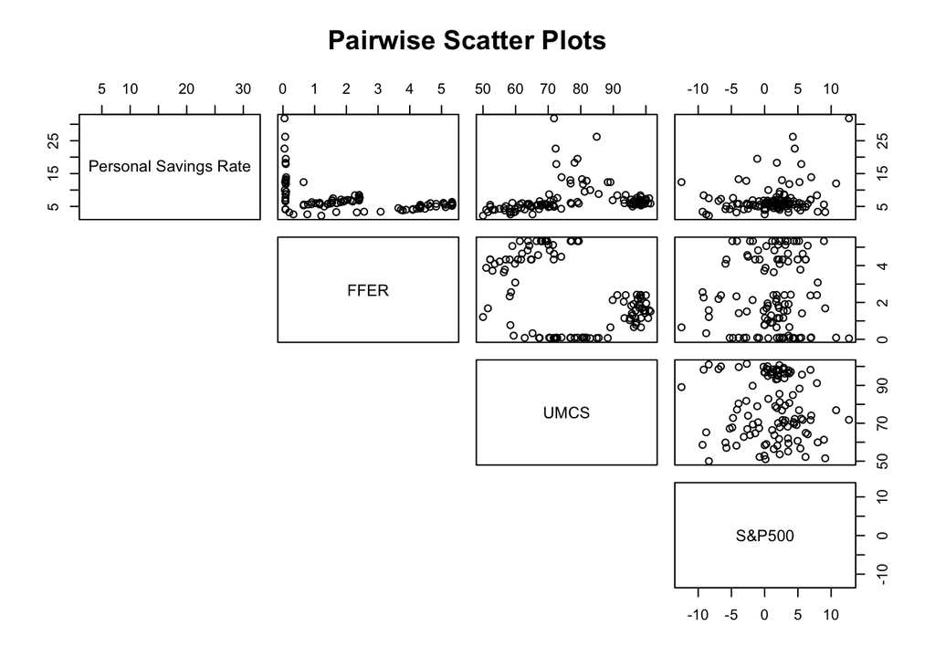

```r
# Pairwise scatter plots and correlations ####
pairs(fred[,1:4], lower.panel = NULL,
      labels = c("Personal Savings Rate", "FFER", "UMCS", "S&P500"),
      main = "Pairwise Scatter Plots")
```

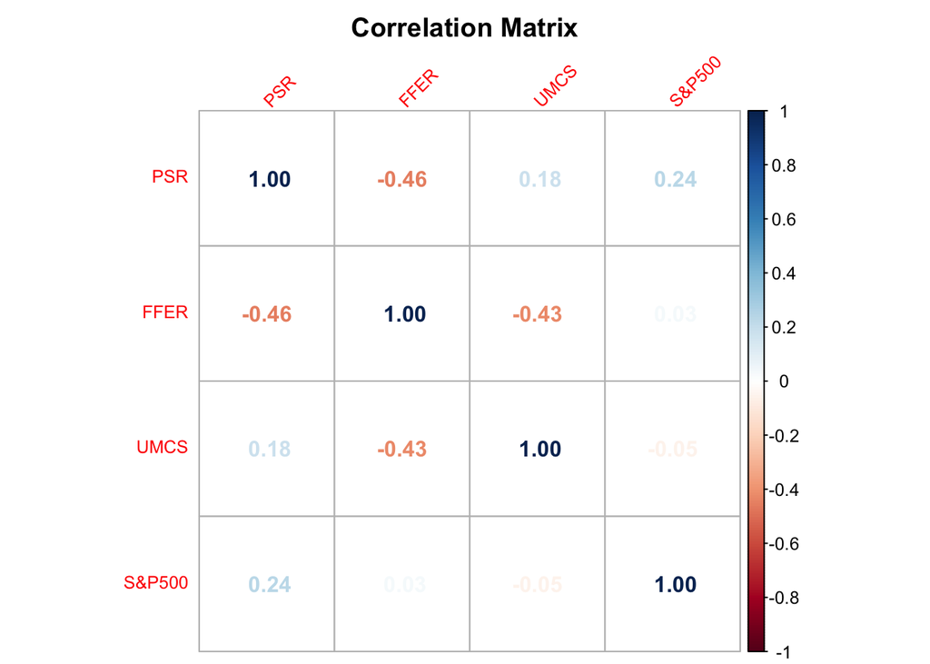

```r
cor_mat <- cor(fred[,1:4])

colnames(cor_mat) <- c("PSR", "FFER", "UMCS", "S&P500")
rownames(cor_mat) <- colnames(cor_mat)


corrplot(cor_mat,
         method = "number",
         number.digits = 2,
         title = "Correlation Matrix",
         mar = c(0, 0, 2, 0),
         tl.cex = 0.8,
         tl.srt = 45)
```

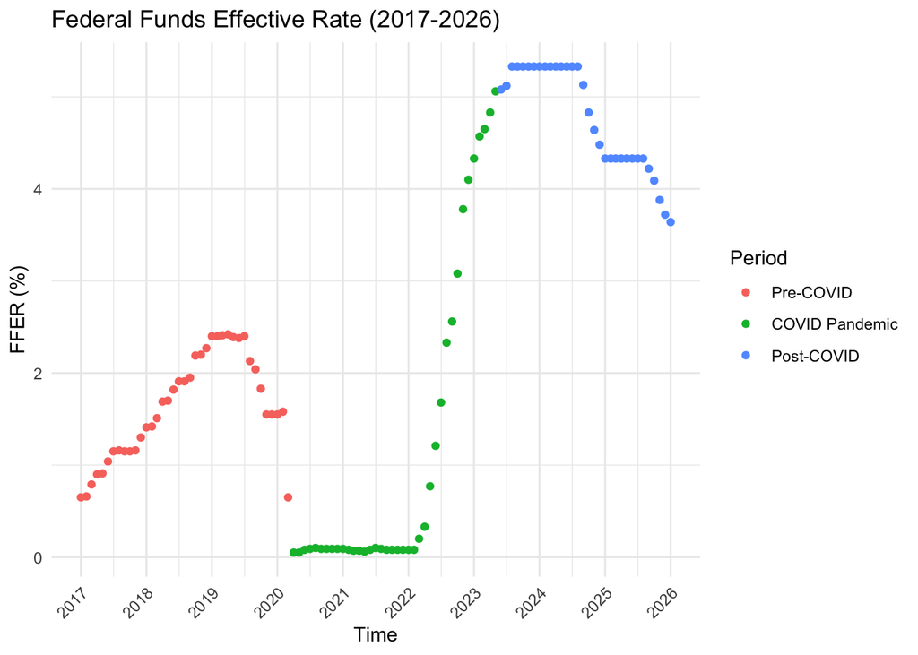

```r
# Univariate scatter plots for variables ####
## FFER ####
fred %>% ggplot(aes(x = observation_date,
                    y = fedfunds,
                    color = factor(covid))) +
  geom_point() +
  labs(title = "Federal Funds Effective Rate (2017-2026)",
       x = "Time",
       y = "FFER (%)",
       color = "Period") +
  scale_color_discrete(labels =
                              c("0" = "Pre-COVID",
                                "1" = "COVID Pandemic",
                                "2" = "Post-COVID")) +
  scale_x_date(date_breaks = "1 year", date_labels = "%Y") +
  theme_minimal() +
  theme(axis.text.x = element_text(angle = 45, hjust = 1))
```

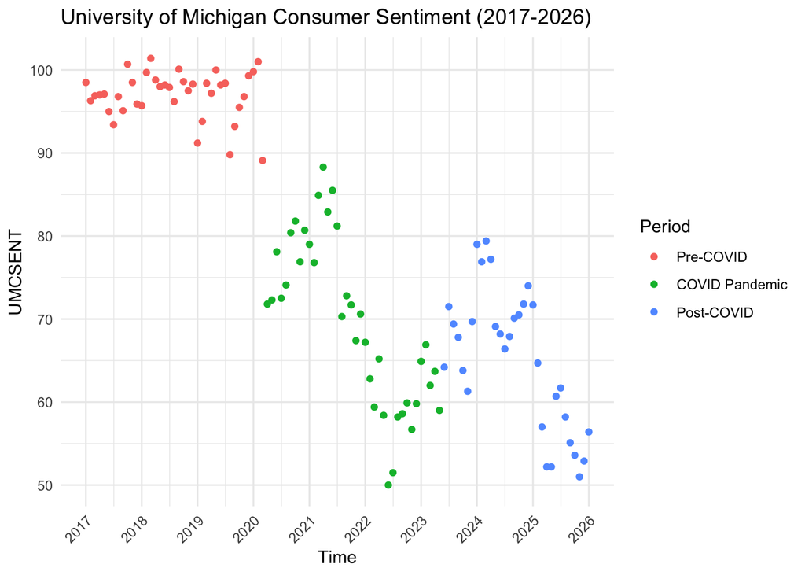

```r
## UMCS ####
fred %>% ggplot(aes(x = observation_date,
                    y = umcsent,
                    color = factor(covid))) +
  geom_point() +
  labs(title = "University of Michigan Consumer Sentiment (2017-2026)",
       x = "Time",
       y = "UMCSENT",
       color = "Period") +
  scale_color_discrete(labels =
                              c("0" = "Pre-COVID",
                                "1" = "COVID Pandemic",
                                "2" = "Post-COVID")) +
  scale_x_date(date_breaks = "1 year", date_labels = "%Y") +
  theme_minimal() +
  theme(axis.text.x = element_text(angle = 45, hjust = 1))
```

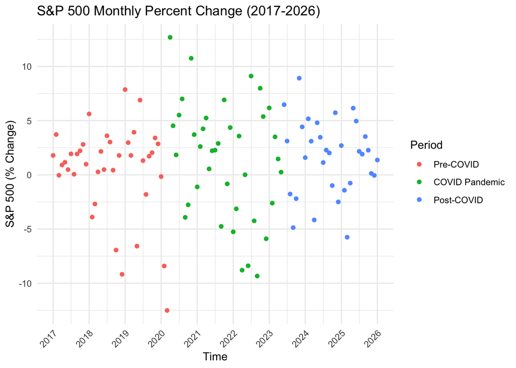

```r
## sp500 percent change ####
fred %>% ggplot(aes(x = observation_date,
                    y = sp500_pch,
                    color = factor(covid))) +
  geom_point() +
  labs(title = "S&P 500 Monthly Percent Change (2017-2026)",
       x = "Time",
       y = "S&P 500 (% Change)",
       color = "Period") +
  scale_color_discrete(labels =
                              c("0" = "Pre-COVID",
                                "1" = "COVID Pandemic",
                                "2" = "Post-COVID")) +
  scale_x_date(date_breaks = "1 year", date_labels = "%Y") +
  theme_minimal() +
  theme(axis.text.x = element_text(angle = 45, hjust = 1))
```

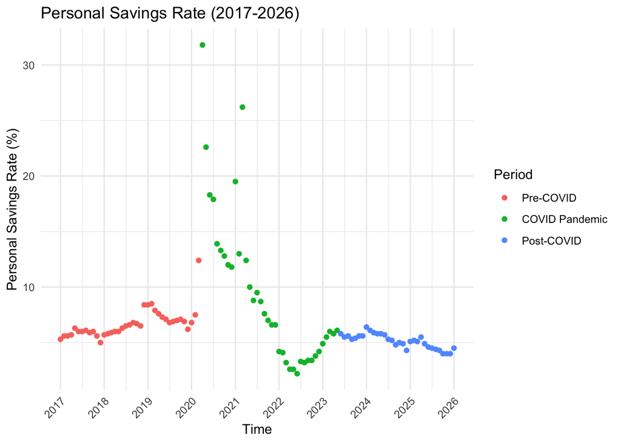

```r
## Personal savings rate ####
fred %>% ggplot(aes(x = observation_date,
                    y = psavert,
                    color = factor(covid))) +
  geom_point() +
  labs(title = "Personal Savings Rate (2017-2026)",
       x = "Time",
       y = "Personal Savings Rate (%)",
       color = "Period") +
  scale_color_discrete(labels =
                              c("0" = "Pre-COVID",
                                "1" = "COVID Pandemic",
                                "2" = "Post-COVID")) +
  scale_x_date(date_breaks = "1 year", date_labels = "%Y") +
  theme_minimal() +
  theme(axis.text.x = element_text(angle = 45, hjust = 1))
```

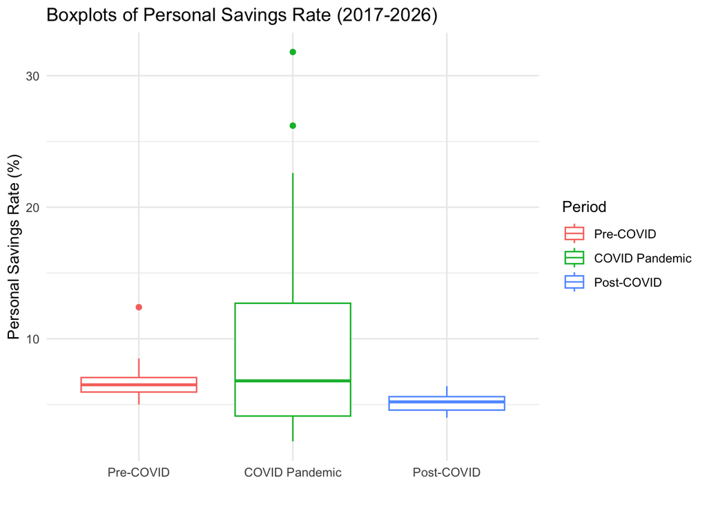

```r
# Box-plot of personal savings rate ####
fred %>% ggplot(aes(x = factor(covid),
                    y = psavert,
                    color = factor(covid))) +
  geom_boxplot() +
  labs(title = "Boxplots of Personal Savings Rate (2017-2026)",
       x = "",
       y = "Personal Savings Rate (%)",
       color = "Period") +
  scale_color_discrete(labels =
                              c("0" = "Pre-COVID",
                                "1" = "COVID Pandemic",
                                "2" = "Post-COVID")) +
  scale_x_discrete(labels = c("Pre-COVID", "COVID Pandemic", "Post-COVID")) +
  theme_minimal()
```

From the pairwise plots and correlation matrix above, we can see that there does not appear to be strong relationships between each of the predictor variables. This supports the assumption of independent predictors for regression analysis. We can also see the change in each of the variables over time in the univariate plots. It appears that there is some effect by the COVID pandemic on the Personal Savings Rate, Consumer Sentiment, and Federal Funds Effective Rate.

It should be noted, however, that there are not strong linear relationships between the 3 predictors and the Personal Savings Rate. Accounting for the COVID pandemic could help explain more as well as accounting for the effect of past months’ FFER on PSR.

The first model that we’ll look at will be an ordinary least squares regression with the Personal Savings Rate being predicted by FFER, UMCS, S&P500, and the COVID period.

## Applying Ordinary Least Squares Regression

```r
# Running 1st OLS model ####
fred$covid <- as.factor(fred$covid)
model_ols = lm(psavert ~ fedfunds + umcsent + sp500_pch +
                 covid, data = fred)
summary(model_ols)
```

```
##
## Call:
## lm(formula = psavert ~ fedfunds + umcsent + sp500_pch + covid,
##     data = fred)
##
## Residuals:
##     Min      1Q  Median      3Q     Max
## -5.3761 -1.8320 -0.4362  0.9350 18.6581
##
## Coefficients:
##              Estimate Std. Error t value Pr(>|t|)
## (Intercept) -13.82472    4.72458  -2.926  0.00422 **
## fedfunds     -0.88875    0.31295  -2.840  0.00544 **
## umcsent       0.22546    0.04661   4.837 4.64e-06 ***
## sp500_pch     0.19383    0.07608   2.548  0.01233 *
## covid1        8.36453    1.55361   5.384 4.61e-07 ***
## covid2        8.18064    1.74860   4.678 8.82e-06 ***
## ---
## Signif. codes:  0 '***' 0.001 '**' 0.01 '*' 0.05 '.' 0.1 ' ' 1
##
## Residual standard error: 3.495 on 103 degrees of freedom
## Multiple R-squared:   0.44,  Adjusted R-squared:  0.4128
## F-statistic: 16.18 on 5 and 103 DF,  p-value: 9.402e-12
```

```r
range(fred$psavert)
```

```
## [1]  2.2 31.8
```

The formula for the OLS model is:

$$\widehat{\text{PSR}} = -13.82 - 0.89
(\text{FFER}) +
0.23 (\text{UMCS}) + 0.19 (\text{S&P500}) + 8.36 (\text{Pandemic})
+ 8.18 (\text{Post-Pandemic})$$

**Explanation:**

For this model, we also have the following: Residual Standard Error: 3.495, R-squared: 0.44, and Adjusted R-squared: 0.4128.

The R-squared value of 0.44 means that this first model explains 44% of the variation in the Personal Savings Rate. Also, for any given predicted value, on average, this model is off by +/- 2 * 3.495 = +/- 6.99 percent. This is quite large, considering that the range of the Personal Savings Rate in our data was from 2.2% to 31.8%. We can also note that all predictors were statistically significant with extreme significance for UMCS and the COVID Period.

### Checking Assumptions

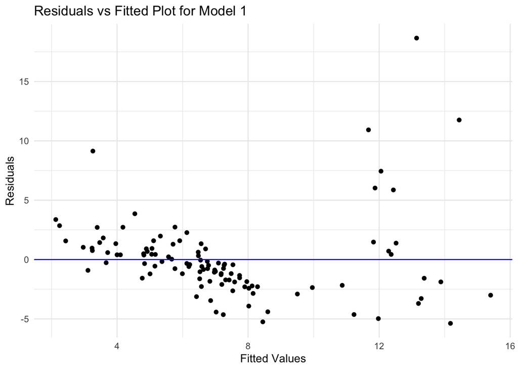

```r
# Fitted values vs residual plot ####
ggplot(model_ols, aes(x = .fitted, y = .resid)) +
  geom_point() +
  geom_hline(yintercept = 0, color = "blue") +
  labs(title = "Residuals vs Fitted Plot for Model 1",
       x = "Fitted Values",
       y = "Residuals") +
  theme_minimal()
```

The funneling effect in the plot above points toward a concern with the assumption of equal variance among the errors. Also, there might also be a pattern present which could point toward an issue with the assumption of linearity.

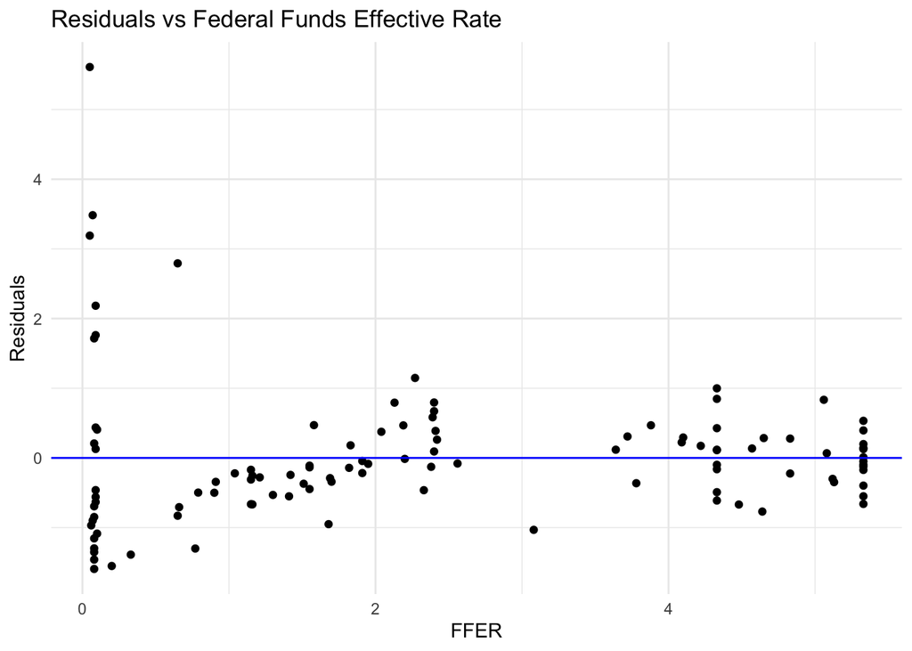

```r
# Plot for standardized residual vs each predictor ####

## Stand. Residuals vs FFER ####
ggplot(fred, aes(x = fedfunds, y = rstandard(model_ols))) +
  geom_point() +
  geom_hline(yintercept = 0, color = "blue") +
  labs(title = "Residuals vs Federal Funds Effective Rate",
       x = "FFER",
       y = "Residuals") +
  theme_minimal()
```

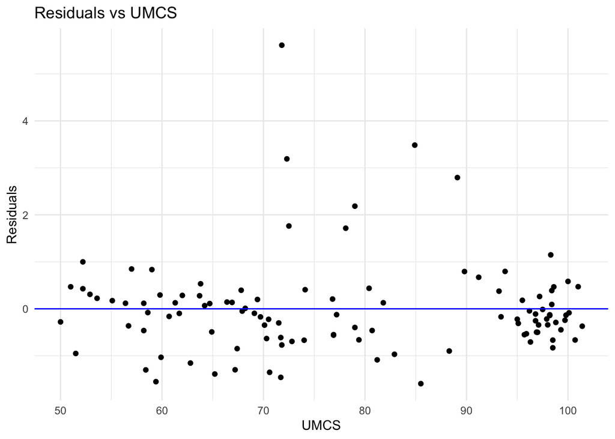

```r
## Stand. Residuals vs UMCS ####
ggplot(fred, aes(x = umcsent, y = rstandard(model_ols))) +
  geom_point() +
  geom_hline(yintercept = 0, color = "blue") +
  labs(title = "Residuals vs UMCS",
       x = "UMCS",
       y = "Residuals") +
  theme_minimal()
```

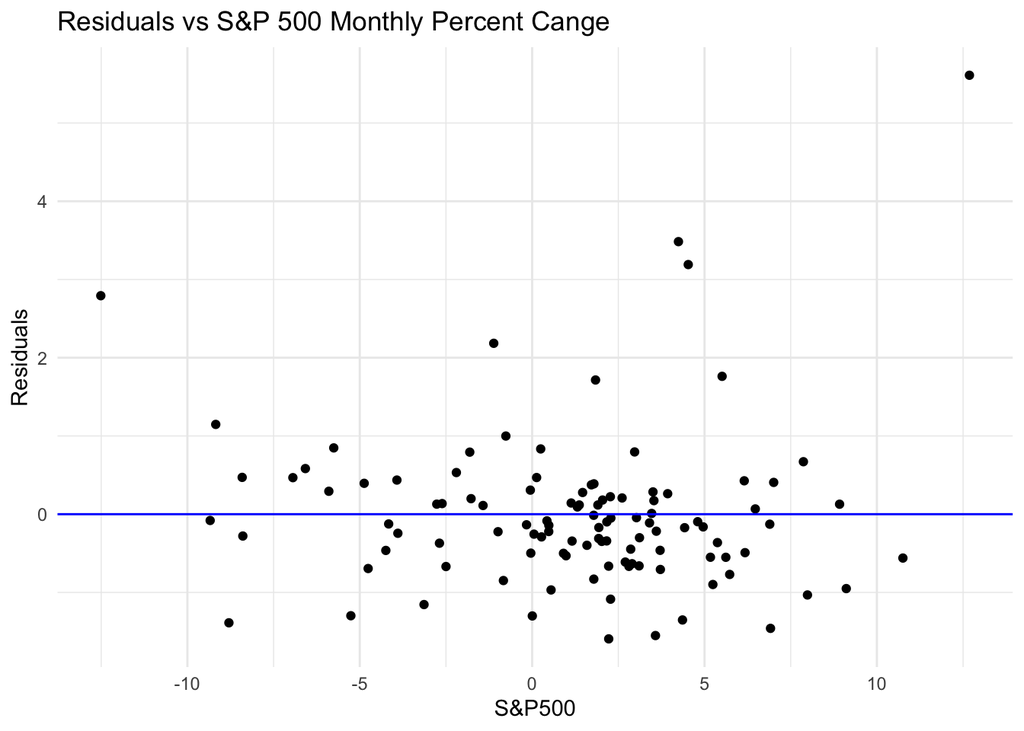

```r
## Residuals vs S&P500 ####
ggplot(fred, aes(x = sp500_pch, y = rstandard(model_ols))) +
  geom_point() +
  geom_hline(yintercept = 0, color = "blue") +
  labs(title = "Residuals vs S&P 500 Monthly Percent Cange",
       x = "S&P500",
       y = "Residuals") +
  theme_minimal()
```

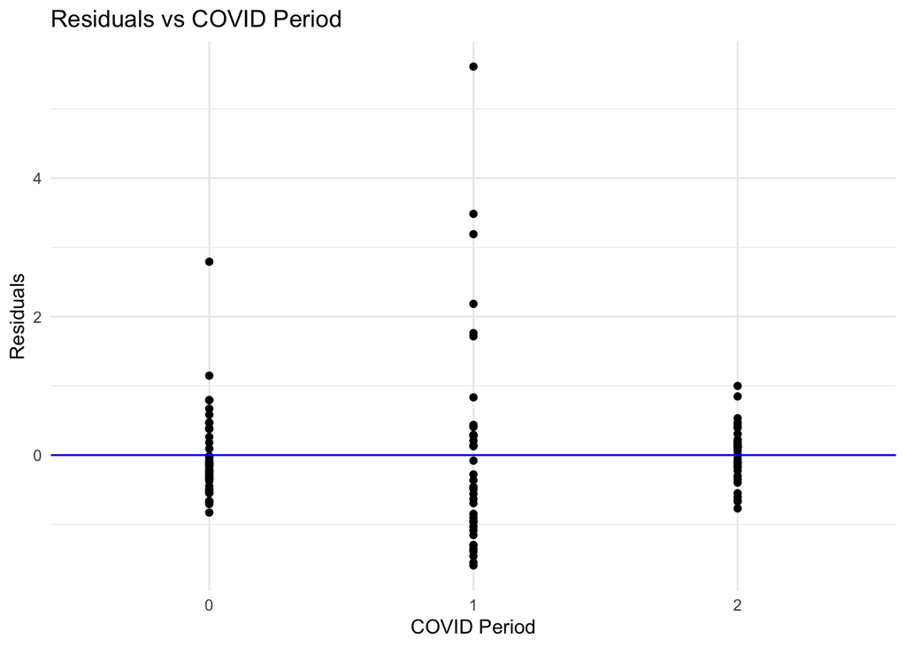

```r
## Residuals vs COVID ####
ggplot(fred, aes(x = covid, y = rstandard(model_ols))) +
  geom_point() +
  geom_hline(yintercept = 0, color = "blue") +
  labs(title = "Residuals vs COVID Period",
       x = "COVID Period",
       y = "Residuals") +
  theme_minimal()
```

In the plots above, there would ideally be a random cloud of points with no pattern, centered along the line y = 0. That being said, there are a few concerning things in each of the plots above. In the residual vs FFER plot, there is much higher error for lower values of FFER. This could indicate outliers in the data. In the residual vs UMCS, there also appear to be some outliers but overall, there appears to be a general cloud of points with no pattern. Finally, in the residual vs S&P 500 plot, there is a random cloud of points, but it appears there could be some outliers as well. The plot of the residuals vs COVID period shows much higher variance during the pandemic.

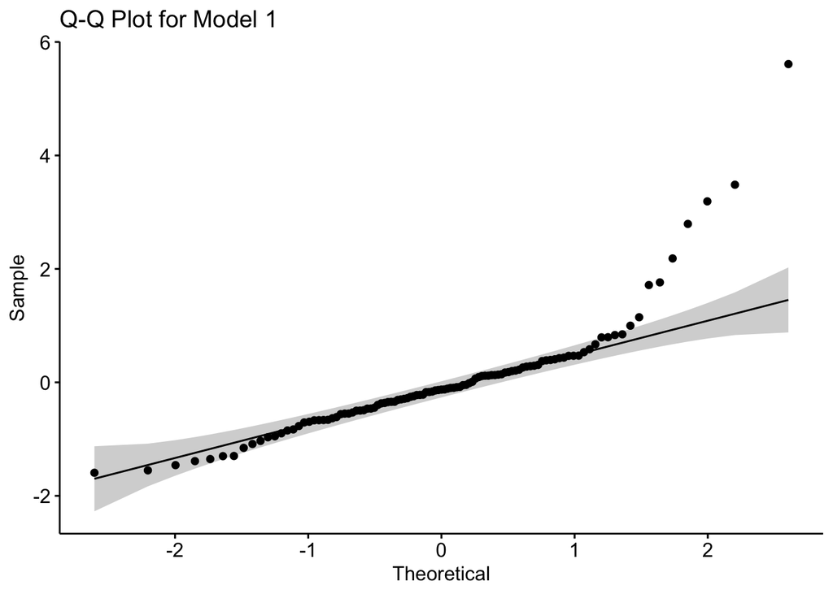

```r
ggqqplot(rstandard(model_ols)) +
  labs(title = "Q-Q Plot for Model 1")
```

From the Q-Q plot above, we can see a generally linear line until the end where they drift away. This points to an issue with our assumption of normality of our errors.

Before applying transformations to our data or removing outliers to try to fix these broken assumptions, let’s investigate the relationship of the past Federal Funds Effective Rate on the Personal Savings Rate as mentioned previously. While the current FFER could have an effect on PSR, there may be a delayed response meaning that a lagged model would more appropriately model the data. To check this, we will test for autocorrelation.

### Checking for Autocorrelation

```r
# Durbin-Watson Test ####
durbinWatsonTest(model_ols)
```

```
##  lag Autocorrelation D-W Statistic p-value
##    1       0.6345811     0.7242475       0
##  Alternative hypothesis: rho != 0
```

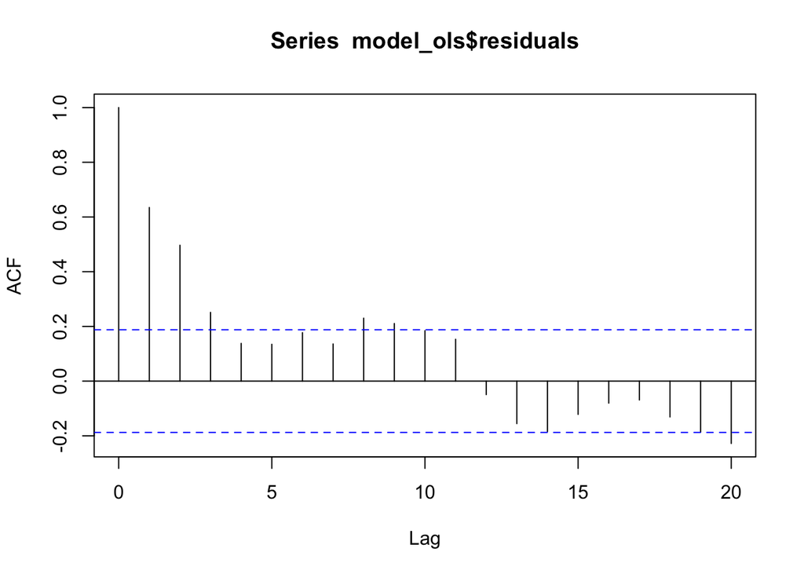

```r
acf(model_ols$residuals)
```

The autocorrelation for this model at lag 1 was 0.635 and was statistically significant. We can also see in the graph above that autocorrelation is a issue at several lags, the first three being the worst. Therefore, we need to account for the broken assumption of independent errors. First, we’ll take a look at the correlation between the savings rate and the lagged predictors, that is, the previous month’s predictor value.

```r
# Correlation between savings rate and lagged predictors ####
# Lag 1
cor(fred$psavert[-1], fred$fedfunds[-nrow(fred)]) #FFER
```

```
## [1] -0.4239329
```

```r
cor(fred$psavert[-1], fred$umcsent[-nrow(fred)]) #UMCS
```

```
## [1] 0.2240834
```

```r
cor(fred$psavert[-1], fred$sp500_pch[-nrow(fred)]) #S&P 500
```

```
## [1] 0.01900089
```

```r
# Lag 2
cor(fred$psavert[-c(1,2)], fred$fedfunds[-c(nrow(fred)-1, nrow(fred))]) #FFER
```

```
## [1] -0.379776
```

```r
cor(fred$psavert[-c(1,2)], fred$umcsent[-c(nrow(fred)-1, nrow(fred))]) #UMCS
```

```
## [1] 0.2818364
```

```r
cor(fred$psavert[-c(1,2)], fred$sp500_pch[-c(nrow(fred)-1, nrow(fred))]) # S&P 500
```

```
## [1] -0.03534895
```

```r
# Lag 3
cor(fred$psavert[-c(1,2,3)],
    fred$fedfunds[-c(nrow(fred)-2, nrow(fred)-1, nrow(fred))]) # FFER
```

```
## [1] -0.3496636
```

```r
# Correlation between savings rate and the previous month's savings rate ####
cor(fred$psavert[-1], fred$psavert[-nrow(fred)]) # lag 1
```

```
## [1] 0.772862
```

```r
cor(fred$psavert[-c(1,2)], fred$psavert[-c(nrow(fred)-1 ,nrow(fred))]) # lag 2
```

```
## [1] 0.6860738
```

The largest correlation between the savings rate and one of the lagged predictors is with the Federal Funds Effective Rate. The correlation with the previous month is -0.42. The correlation with two months prior is -0.38 and with three months prior, the correlation is -0.35. These are not considered high correlation typically. However, correlation between the savings rate and the previous month’s savings rate is very high at 0.77. And at two months apart, it is 0.69. To try to correct the autocorrelation in our model, we will include the previous month’s savings rate as a predictor.

## Correcting for Autocorrelation

```r
# Including a lagged PSR predictor ####
fred <- fred %>%
  mutate(psavert_lag1 = lag(psavert))

model_lag = lm(psavert ~ psavert_lag1 + fedfunds +  umcsent + sp500_pch + covid,
               data = fred)

summary(model_lag)
```

```
##
## Call:
## lm(formula = psavert ~ psavert_lag1 + fedfunds + umcsent + sp500_pch +
##     covid, data = fred)
##
## Residuals:
##     Min      1Q  Median      3Q     Max
## -9.1885 -0.7666 -0.2251  0.2813 19.0152
##
## Coefficients:
##              Estimate Std. Error t value Pr(>|t|)
## (Intercept)  -3.55887    4.14086  -0.859   0.3921
## psavert_lag1  0.60777    0.08566   7.095 1.82e-10 ***
## fedfunds     -0.32855    0.27093  -1.213   0.2281
## umcsent       0.07025    0.04411   1.593   0.1144
## sp500_pch     0.09889    0.06405   1.544   0.1257
## covid1        2.52577    1.51527   1.667   0.0986 .
## covid2        2.36655    1.65362   1.431   0.1555
## ---
## Signif. codes:  0 '***' 0.001 '**' 0.01 '*' 0.05 '.' 0.1 ' ' 1
##
## Residual standard error: 2.874 on 101 degrees of freedom
##   (1 observation deleted due to missingness)
## Multiple R-squared:  0.6281, Adjusted R-squared:  0.6061
## F-statistic: 28.44 on 6 and 101 DF,  p-value: < 2.2e-16
```

```r
confint(model_lag)
```

```
##                     2.5 %    97.5 %
## (Intercept)  -11.77321933 4.6554710
## psavert_lag1   0.43782939 0.7777020
## fedfunds      -0.86600411 0.2088971
## umcsent       -0.01725437 0.1577448
## sp500_pch     -0.02815712 0.2259470
## covid1        -0.48012148 5.5316547
## covid2        -0.91379597 5.6468910
```

After including the previous month’s savings rate as a predictor, we have a model where the previous month’s savings rate is the only significant predictor at a 5% level. Our new model is:

$$\widehat{\text{PSR}} = -3.56 + 0.61
(\text{Prev. PSR}) - 0.33 (\text{FFER}) +
0.07 (\text{UMCS}) + 0.1 (\text{S&P500}) \\ + 2.53 (\text{Pandemic})
+ 2.37 (\text{Post-Pandemic})$$

**Explanation**  
For this model, we also have:  
Residual Standard Error: 2.874, R-squared: 0.63 Adjusted, R-squared: 0.6061

### Checking Assumptions

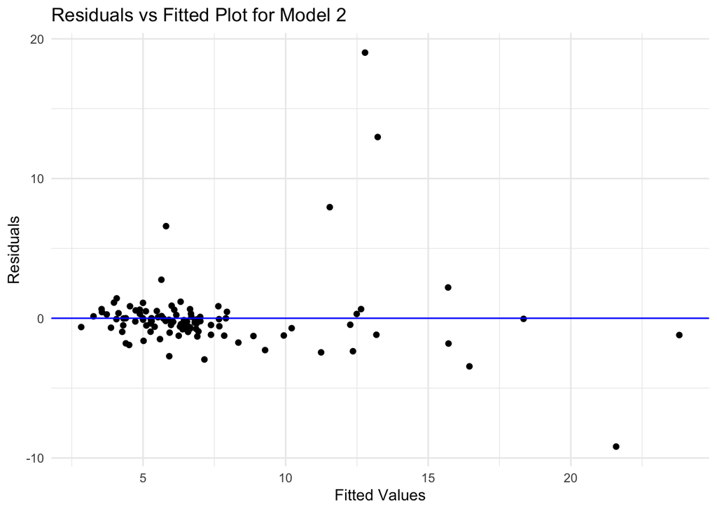

```r
# Fitted values vs residual plot ####
ggplot(model_lag, aes(x = .fitted, y = .resid)) +
  geom_point() +
  geom_hline(yintercept = 0, color = "blue") +
  labs(title = "Residuals vs Fitted Plot for Model 2",
       x = "Fitted Values",
       y = "Residuals") +
  theme_minimal()
```

The plot above of fitted values vs residuals shows a funnel shape. This indicates that there is still a problem with the assumption of equal variance. There does not appear to be a pattern however, which means our assumption of linearity is likely not broken.

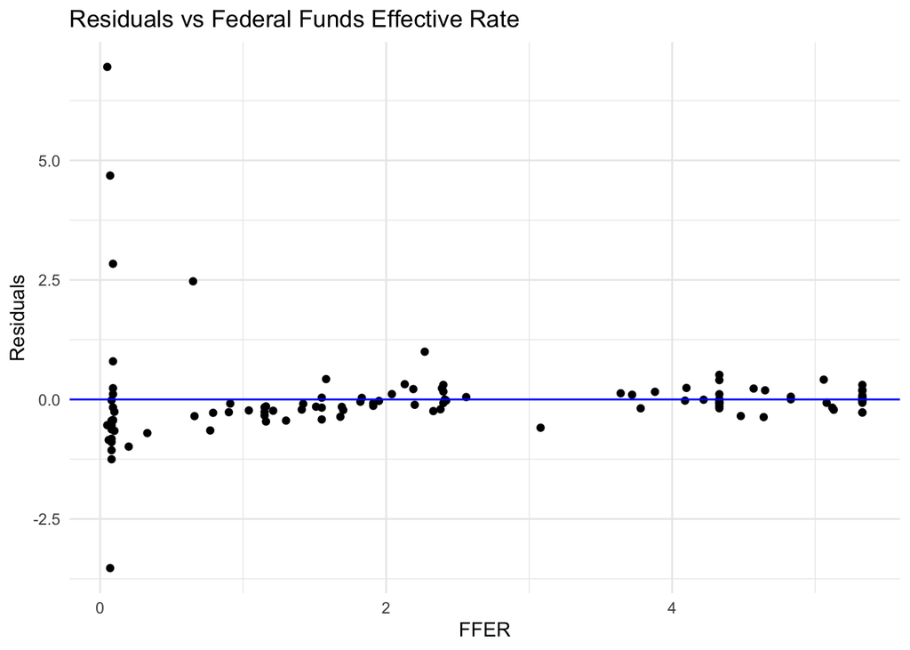

```r
# Plot for standardized residual vs each predictor ####
fred_aug <- augment(model_lag)

## Stand. Residuals vs FFER ####
ggplot(fred_aug, aes(x = fedfunds, y = rstandard(model_lag))) +
  geom_point() +
  geom_hline(yintercept = 0, color = "blue") +
  labs(title = "Residuals vs Federal Funds Effective Rate",
       x = "FFER",
       y = "Residuals") +
  theme_minimal()
```

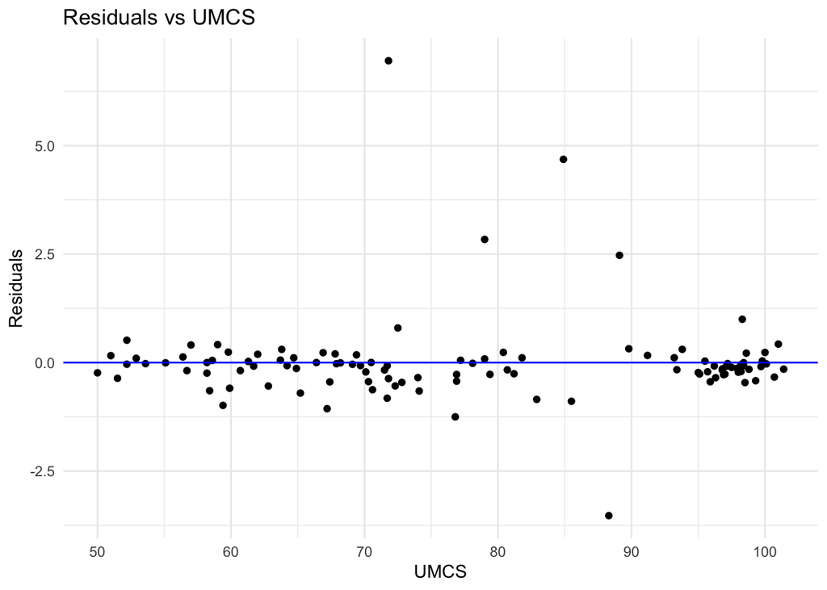

```r
## Stand. Residuals vs UMCS ####
ggplot(fred_aug, aes(x = umcsent, y = rstandard(model_lag))) +
  geom_point() +
  geom_hline(yintercept = 0, color = "blue") +
  labs(title = "Residuals vs UMCS",
       x = "UMCS",
       y = "Residuals") +
  theme_minimal()
```

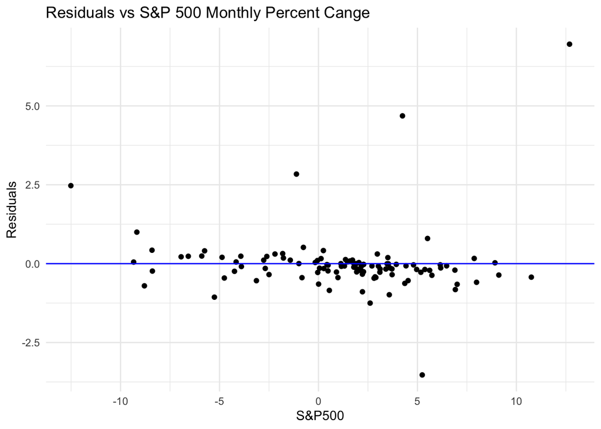

```r
## Residuals vs S&P500 ####
ggplot(fred_aug, aes(x = sp500_pch, y = rstandard(model_lag))) +
  geom_point() +
  geom_hline(yintercept = 0, color = "blue") +
  labs(title = "Residuals vs S&P 500 Monthly Percent Cange",
       x = "S&P500",
       y = "Residuals") +
  theme_minimal()
```

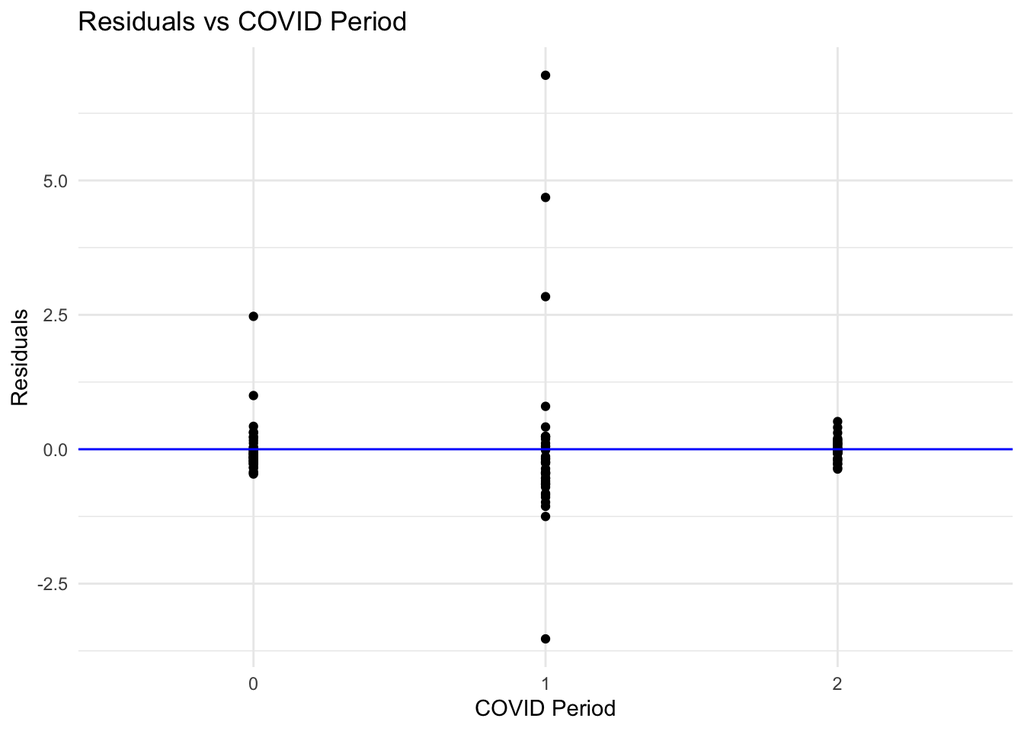

```r
## Residuals vs COVID ####
ggplot(fred_aug, aes(x = covid, y = rstandard(model_lag))) +
  geom_point() +
  geom_hline(yintercept = 0, color = "blue") +
  labs(title = "Residuals vs COVID Period",
       x = "COVID Period",
       y = "Residuals") +
  theme_minimal()
```

Based on the plots above, even after accounting for autocorrelation, there are still broken assumptions with equal variance.

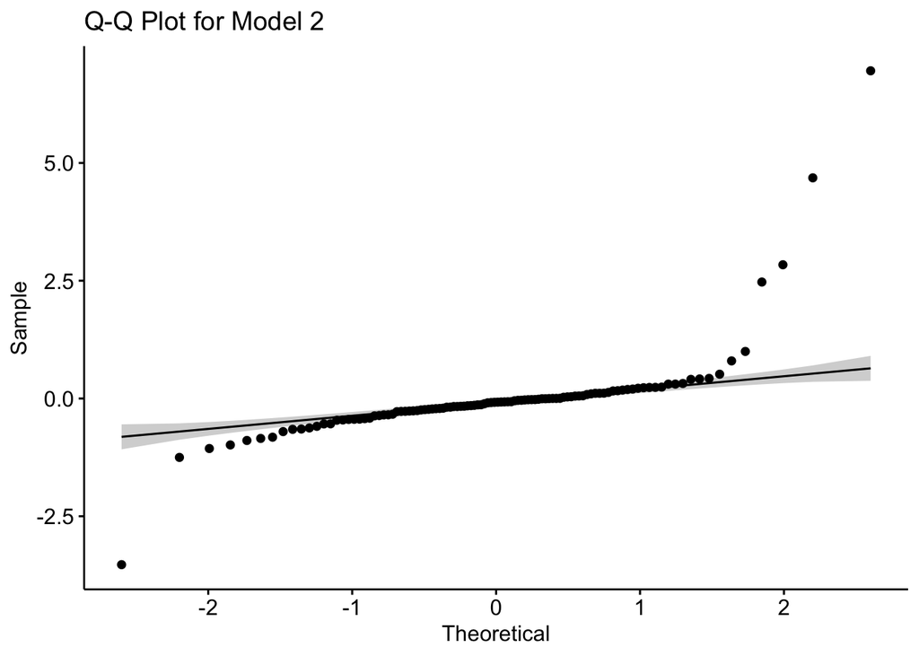

```r
# Checking normality ####
ggqqplot(rstandard(model_lag)) +
  labs(title = "Q-Q Plot for Model 2")
```

From the Q-Q plot, we can also see an issue with the assumption of normality.

## Making Predictions for March 2026

```r
#UMCS F MAR 53.3
march_data = data.frame(
  psavert_lag1 = 4.0,
  fedfunds = 3.64,
  umcsent = 53.3,
  sp500_pch = -5.1,
  covid = factor(2)
)

predict(model_lag,
        newdata = march_data,
        interval = "prediction",
        level = 0.95)
```

```
##        fit       lwr      upr
## 1 3.282508 -2.684962 9.249978
```

Using our second model, the predicted savings rate for March 2026 is 3.28% (95% CI: -2.68, 9.25). Considering the broken assumptions mentioned above and the huge confidence interval, this prediction is not to be relied on.

# Validity and Conclusion

Because of the multiple broken assumptions with our second model, there is still significant concern with its validity.Further time-series specific transformations or adjustments should be used to try to fix these. This was only a brief overview of this topic and much more could be done to try to better answer the stated objective. Our original model, while containing multiple significant predictors, broke multiple statistical assumptions as well. Our second model does appear to break multiple assumptions but perhaps not as severely. Neither effectively answers our research question or should probably not be relied on to predict future savings rate values. A possible alternative for future research would be to use three models, one for pre-pandemic, for the pandemic, and post-pandemic.

## Citations

University of Michigan, University of Michigan: Consumer Sentiment [UMCSENT], retrieved from FRED, Federal Reserve Bank of St. Louis; https://fred.stlouisfed.org/series/UMCSENT, (Accessed on 6 April 2026).

S&P Dow Jones Indices LLC, S&P 500 [SP500], retrieved from FRED, Federal Reserve Bank of St. Louis; https://fred.stlouisfed.org/series/SP500, (Accessed on 6 April 2026).

U.S. Bureau of Economic Analysis, Personal Saving Rate [PSAVERT], retrieved from FRED, Federal Reserve Bank of St. Louis; https://fred.stlouisfed.org/series/PSAVERT, (Accessed on 6 April 2026).

Board of Governors of the Federal Reserve System (US), Federal Funds Effective Rate [FEDFUNDS], retrieved from FRED, Federal Reserve Bank of St. Louis; https://fred.stlouisfed.org/series/FEDFUNDS, (Accessed on 6 April 2026).